# Applied Microeconometrics

## Fitting Model

### I-K Optimal Bandwith Local Linear Regression

```r
rdmod <- RDestimate(change_pass ~ vote, data=df, cutpoint=50)
```

and plot the regression:

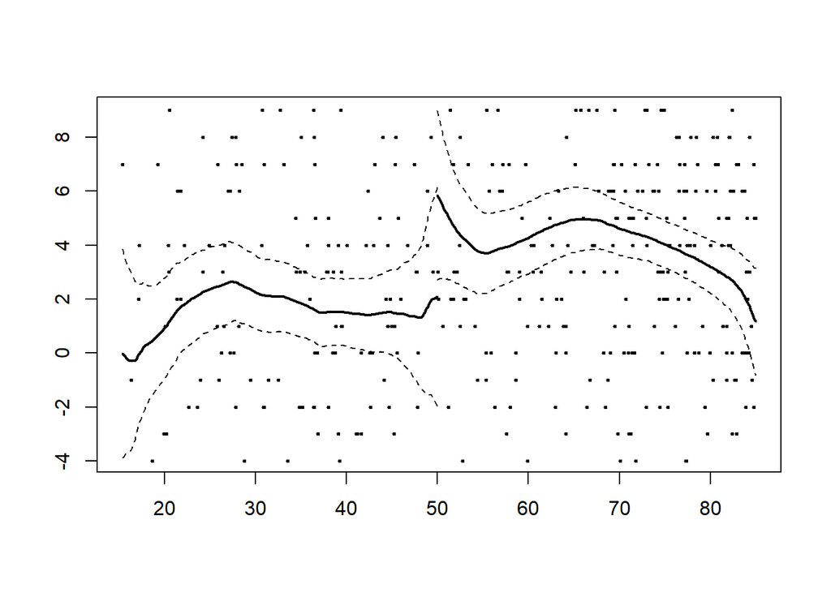

```r
plot(rdmod, main='Regression Discontinuity',xlab='Vote',ylab='Change in PassRate')
```

If we have a smaller bandwidth, standard error gets larger. This is the well known bias-variane trade-off. If we have a smaller bandwidth, it is more likely that the populations below and above the threshold are similar so that the coefficient on win has smaller bias, but having smaller bandwidth means we have fewer observations, which results in larger standard error.

### Polynomial Regression

```r
# instead of rdd package, use lm() function
rdmod1 <- lm(change_pass ~ win, data=df)
rdmod2 <- lm(change_pass ~ win + margin, data=df)
rdmod3 <- lm(change_pass ~ win + margin*win + margin*lose, data=df)
rdmod4 <- lm(change_pass~win + margin + win*margin + lose*margin + win*margin^2 + lose*margin^2, data=df)
stargazer(rdmod1, rdmod2, rdmod3, rdmod4, type='text', title='RDD Models with Different Sets of Variables', style='aer')
```

```
##
## RDD Models with Different Sets of Variables
## ================================================================================================================
##                                                             change_pass
##                               (1)                    (2)                    (3)                    (4)
## ----------------------------------------------------------------------------------------------------------------
## win                        2.169***                4.052***               12.233*                12.233*
##                             (0.634)                (1.282)                (7.061)                (7.061)
##
## margin                                             -0.053*                 -0.019                 -0.019
##                                                    (0.031)                (0.056)                (0.056)
##
## lose                                                                       8.510                  8.510
##                                                                           (7.081)                (7.081)
##
## win:margin                                                                 -0.046                 -0.046
##                                                                           (0.067)                (0.067)
##
## margin:lose
##
##
## Constant                   1.755***                 0.943                  -7.000                 -7.000
##                             (0.501)                (0.694)                (7.009)                (7.009)
##
## Observations                  524                    524                    524                    524
## R2                           0.022                  0.027                  0.031                  0.031
## Adjusted R2                  0.020                  0.024                  0.023                  0.023
## Residual Std. Error    7.020 (df = 522)        7.007 (df = 521)       7.009 (df = 519)       7.009 (df = 519)
## F Statistic         11.710*** (df = 1; 522) 7.301*** (df = 2; 521) 4.087*** (df = 4; 519) 4.087*** (df = 4; 519)
## ----------------------------------------------------------------------------------------------------------------
## Notes:              ***Significant at the 1 percent level.
##                     **Significant at the 5 percent level.
##                     *Significant at the 10 percent level.
```

### Different Subsets of Data

If we have data on outcome variable prior to the treatment, then we can use this data to check whether the populations below and above the threshold are similar. We want the two populations to be clones of each other and so we want them to be similar not only interms of the unobservables but also the observables.

```r
rdmod5 <- lm(change_pass ~ win + margin:win + margin:lose, data=df, subset=(vote<=85 & vote >= 15))
rdmod6 <- lm(change_pass ~ win + margin:win + margin:lose, data=df, subset=(vote<=70 & vote >= 30))
rdmod7 <- lm(change_pass ~ win + margin:win + margin:lose, data=df, subset=(vote<=55 & vote >= 45))
stargazer(rdmod5, rdmod6, rdmod7, title='Impact of GM Status on Pass Rates of School: Two Years after Base Year',style='aer', type='text')
```

```
##
## Impact of GM Status on Pass Rates of School: Two Years after Base Year
## ======================================================================================
##                                                change_pass
##                              (1)                    (2)                   (3)
## --------------------------------------------------------------------------------------
## win                        3.894***                2.753                 6.545*
##                            (1.314)                (1.823)               (3.850)
##
## win:margin                 -0.064*                 0.060                 -1.575
##                            (0.038)                (0.103)               (0.960)
##
## margin:lose                 -0.027                 -0.015                0.535
##                            (0.056)                (0.119)               (0.938)
##
## Constant                    1.339                  1.303                 1.849
##                            (0.995)                (1.349)               (2.932)
##
## Observations                 524                    273                    62
## R2                          0.028                  0.048                 0.127
## Adjusted R2                 0.022                  0.037                 0.081
## Residual Std. Error    7.012 (df = 520)       7.335 (df = 269)      7.629 (df = 58)
## F Statistic         4.964*** (df = 3; 520) 4.493*** (df = 3; 269) 2.800** (df = 3; 58)
## --------------------------------------------------------------------------------------
## Notes:              ***Significant at the 1 percent level.
##                     **Significant at the 5 percent level.
##                     *Significant at the 10 percent level.
```